# Lab 09: Logistic Regression

# Permissions and IAM roles

This assignment assumes that you are running RStudio on an Amazon EC2 instance created from AMI `FIN550-RStudio` and IAM role `BigDataEC2Role`.

In this assignment, you will transfer files between your EC2 instance and S3 using file commands from the [AWS Command Line Interface (CLI)](https://aws.amazon.com/cli/#file_commands_anchor). When a file request is made to an S3 bucket, AWS checks to see if the request is coming from an account that is authorized to make the file request. The class S3 bucket at `s3://bigdata-fin550-league` can only be accessed by AWS EC2 instances with the IAM role `BigDataEC2Role` attached. You will also be able to access S3 buckets that you create, such as `s3://fin550-assignments-netid`.

To confirm that the IAM role `BigDataEC2Role` is correctly attached, select your instance from the Amazon EC2 Console. You should see the role listed under the Description tab.

# Lab workflow

Create a folder for today’s lab. In the RStudio File window, create a New Folder under your home directory at `~/fin550/lab-09`. Copy the file `lab-09.Rmd` from the course S3 lab repository at `s3://bigdata-fin550-league` to your `lab-09` folder by entering the following Unix command. RStudio allows you to execute operating system commands using the built-in shell, found at `Tools` > `Shell`.

```bash
# This is a Unix command. Enter via RStudio Shell
aws s3 cp --recursive s3://bigdata-fin550-league/lab-09 ~/fin550/lab-09
```

Navigate to the `~/fin550/lab-09` lab directory, and open the assignment template `lab-09.Rmd`. Edit the template to answer the questions and complete the assignment.

# Identifying competitive auctions on eBay.com

The file **eBayAuctions.csv** contains information on 1972 auctions transacted on eBay.com during May-June 2004. The goal is to use this data to build a model that will distinguish competitive auctions from non-competitive auctions. A competitive auction is defined as an auction with at least two bids placed on the item being auctioned. The binary outcome variable (Competitive.) takes on a value of 1 if the auction is competitive and a value of 0 if it is not competitive. The data includes variables that describe the item (e.g., auction category), the seller (e.g., his or her eBay rating), and the auction terms that the seller selected (e.g., auction duration, opening price, currency, and day of week that the auction closed). In addition, we include the price at which the auction closed. The following table describes each of the predictors and the response.

**DESCRIPTION OF VARIABLES FOR AUCTIONS ON EBAY.COM EXAMPLE**

| Competitive. | Whether the auction had a single bid (0) or more (1) |
| --- | --- |
| Category | Category of the auctioned item |
| currency | Currency |
| sellerRating | A rating by eBay, as a function of the number of good and bad transactions |
| Duration | Number of days the auction lasted |
| endDay | Day of week that the auction closed |
| ClosePrice | Price item sold |
| OpenPrice | Initial price set by the seller |

## 0 Load the packages and suppress scientific notation

Use `library()` to load `caret` and `gains`. Use `options(scipen=999)` to suppress scientific notation.

## 1 Create a data frame

Load the data with `read.csv()`. Use parameter `stringsAsFactors = FALSE` to prevent character variables from converting to categorical variables, because we will modify the values of character variables later. Save the result in a data frame named `ebay.df`.

Use `head()` and `names()` to return the first six rows and column names.

## 2 Apply a function to each group

Compute the mean of the binary outcome variable (`ebay.df$Competitive.`) for each day of the week that the auction closed (`ebay.df$endDay`).

Compute the mean of the binary outcome variable (`ebay.df$Competitive.`) for each auction category (`ebay.df$Category`).

Hint: function `tapply()` applies a function to each group. The first parameter in the function is the binary outcome variable, the second parameter is the variable used for grouping, and the third parameter is the function (`mean`).

## 3 Reduce levels in the day of week that the auction closed (`endDay`)

To reduce the number of dummies that will be used in the model, categories that appear most similar with respect to the distribution of competitive auctions (`Competitive.`) could be combined.

The auction ending days “Sun” and “Fri” have approximately equal average values of competitive auctions (`Competitive.`). Therefore, combine them into a single category called “Sun_Fri”.

Hint: `ebay.df$endDay == "Sun"` selects rows where the value in the variable `endDay` is “Sun”. `ebay.df$endDay[ebay.df$endDay == "Sun"] <- "Sun_Fri"` assigns a new value to `endDay` for these rows.

## 4 Reduce levels in auction categories (`Category`)

The categories “Business/Industrial” and “Computer” have the same average values of the binary variable `Competitive.`. Hence, we can combine the two categories into a single category called “Computer”.

Similarly, the average values of `Competitive.` for categories “Antique/Art/Craft” and “Collectibles” are almost the same. Thus, we can combine them into a single category called “Collectibles”.

Hint: assign a new value “Computer” to the variable Category for rows where the Category value is “Business/Industrial”. Assign a new value ” Collectibles ” to the variable Category for rows where the Category value is “Antique/Art/Craft”.

## 5 Convert `Duration` to a categorical or factor variable

Auction duration (`Duration`) takes on 5 numeric values: 1, 3, 5, 7, and 10. Convert `Duration` to a categorical or factor variable using `as.factor()`.

Use `str()` to return the data type of variables in the data frame. `Duration` should be a factor variable with 5 levels. Logistic regression models will automatically create four dummy variables from the factor’s five levels.

## 6 Data partition

Partition the data into training (60%) and test (40%) sets: use `set.seed(1)` to set the random seed and `sample()` to take a sample of row numbers for the training set. Save a sample of row numbers, the training set, and the test set as `train.index`, `train.df` and `test.df`, respectively.

Hint: `dim(ebay.df)[1]` returns the total number of the rows in the data frame, `0.6*dim(ebay.df)[1]` specifies the number of rows to select for the training set, and `c(1:dim(ebay.df)[1])` represents row numbers.

## 7 Fit a logistic regression model

To predict whether an auction is competitive or not, fit a logistic regression model with all predictors using `glm()` with `family = "binomial"`. Save the result as `reg`.

Use `summary()` to print the summary table of the regression. Notice that 4 dummies variables are created for the categorical variable `Duration`, which has 5 levels. Dummy variables are also automatically created for character variables such as `Category`, `currency`, and `endDay`.

## 8 Generate predicted probabilities

Use `predict()` with `type = "response`” to compute predicted probabilities for auctions in the test set `test.df`.

Save the predicted probabilities as `pred` and return the first six values using `head()`.

## 9 Create a confusion matrix

Use `confusionMatrix()` to create a confusion matrix for records in the test set `test.df`.

Use 0.5 as the threshold or cutoff value: an auction is competitive if the predicted probability is more than 0.5 and an auction is not competitive if the predicted probability is less than or equal to 0.5.

Hint: `ifelse(pred > 0.5, 1, 0)` returns 1 if the predicted probability is more than 0.5 and 0, otherwise.

The first parameter in function `confusionMatrix()` from the `caret` library is a factor of **predicted** classes and the second parameter is a factor of **actual** classes. Use `as.factor()` to convert observed and predicted classes to factors.

Given that the outcome variable `Competitive.` is “1” for competitive auctions, set the third parameter named positive to “1” to specify the positive class.

## 10 Create a gain table [optional]

Use `gains()` from the `gain` library to rank records in the test set `test.df` based on the predicted probabilities of being competitive and group auctions into 10 groups. Save the result as `gain`.

Hint: the first parameter in the function `gains()` is a vector of actual classes (=1 for competitive auctions and 0 for non-competitive auctions). The second parameter is a vector of predicted probabilities computed in question 8. Set the third parameter named groups to 10.

Try the following values returned from the object `gain`:

- `gain$cume.pct.of.total`: returns the cumulative percentage of competitive auctions.
- `gain$cume.obs`: returns the cumulative number of auctions.

## 11 Plot a lift chart [optional]

Use `plot()` to plot the cumulative number of competitive auctions against the cumulative number of auctions.

Hint: `gain$cume.pct.of.total*sum(test.df$Competitive.)` returns the cumulative number of competitive auctions, where `sum(test.df$Competitive.)` represents the total number of competitive auctions. Therefore, `c(0,gain$cume.pct.of.total*sum(test.df$Competitive.))` are the y-axis values.

Specify the x-axis label as “cumulative number of auctions”, y-axis label as “cumulative number of competitive auctions”, and the type is a line plot (`type="l"`).

Use `lines()` to add a diagonal benchmark line, which represents a naïve prediction for each auction and accumulates the average value of competitive auctions in each group.

Hint: `dim(test.df)[1]` returns the total number of auctions. Therefore, `c(0, dim(test.df)[1])` are the x-axis values.

The plot looks like the following graph.

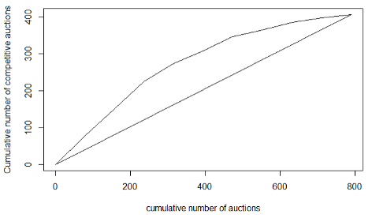

# Assignment submission

After completing the assignment, you should have two files in your`~/fin550/lab-09` lab directory: the Markdown file `lab-09.Rmd` and the corresponding output file `lab-09.html`. Upload both of these files to your S3 assignments bucket, in a folder called `lab-09`. Running the following S3 file command from the Shell in RStudio will automatically created the `lab-09` folder when uploading the respective files (change `netid` to your own). You can navigate to the S3 Management Console in your browser to confirm that the upload was successful.

```bash
# This is a Unix command. Enter via RStudio Shell
# **IMPORTANT** Replace <netid> with your netid before running the following command
aws s3 cp --recursive ~/fin550/lab-09 s3://fin550-assignments-<netid>/lab-09
```